# Kick Google Scholar Up a Notch: Plot annual publications and citations by authorship position

**By:** [Sam Zipper](https://www.twitter.com/ZipperSam)

**Date:** Published February 27, 2019; updated July 26, 2019

(If you just want the code, [go here](https://github.com/samzipper/SelfAnalysis/blob/master/PlotPubsAndCitations.R).)

Maybe you’re applying for a job or going up for tenure, and are trying to demonstrate your research output in a unique way. In academia, the number of publications and citations are commonly used as indicators of productivity and influence - the hypothesis being that productive people are writing more papers and influential people are being cited more. The [limitations](https://thebibliomagician.wordpress.com/2018/03/23/is-it-time-to-bury-the-h-index/) of these [metrics](http://blog.impactstory.org/four-great-reasons-to-stop-caring-so-much-about-the-h-index/) have [long been noted](http://blogs.nature.com/nautilus/2007/10/the_hindex_has_its_flaws.html), so I won’t belabor them here.

Nevertheless, some people in positions of power care about publications and citations, so we might as well show these metrics in a user-friendly manner. I like making graphs so I decided to put a couple simple graphs on the front page of my CV. Since one of the critiques of citation analysis is that it doesn’t account for different authorship roles, I wanted to separately show the data for papers on which I was the first author since I made the primary intellectual contribution for those studies. I don’t know if putting graphs in CVs is normal, but I was complimented on it during multiple job interviews, so in the end I’m glad I bothered.

Let’s set up our environment. We’ll use the [`scholar` package](https://github.com/jkeirstead/scholar) to get the data, then rearrange it a bit with `dplyr`, `reshape2`, and `stringr`, and finally plot with `ggplot2`. So, let’s load some packages!

```r
require(scholar)  # interface with google scholar
require(ggplot2)  # for plotting
require(dplyr)    # for data tidying
require(stringr)  # for working with string data
```

To get your data from Google Scholar, first you have to determine your Google Scholar ID. You can get this from the characters after the `=` in your Google Scholar URL. For instance, [my Google Scholar URL](https://scholar.google.ca/citations?user=XXIpO1YAAAAJ) is `https://scholar.google.ca/citations?user=XXIpO1YAAAAJ`, so I know my ID is `XXIpO1YAAAAJ`.

```r
me <- "XXIpO1YAAAAJ"
```

It’s easy to get a list of all your publications using the `get_publications()` function:

```r
pubs <-
  scholar::get_publications(me) %>%
  # get rid of non-journal articles (e.g. theses) - in my profile, these don't have a year
  subset(is.finite(year))
```

The `author` field has a comma-separated list of all the authors for each publication. Since I want to separately plot publications I first-authored, I need to isolate the first author for each paper:

```r
pubs$first_author <-
  # the 'author' column is a factor by default, so first convert to character
  pubs$author %>%
  as.character() %>%
  # split based on commas and grab the first author only
  strsplit(split="[,]") %>%
  sapply(function(x) x[1])

# look at the results
pubs$first_author
```

```
##  [1] "SC Zipper"          "SC Zipper"          "SC Zipper"
##  [4] "SC Zipper"          "M Motew"            "Y Kang"
##  [7] "SC Zipper"          "EG Booth"           "SC Zipper"
## [10] "J Qiu"              "J Qiu"              "JE Vonk"
## [13] "B Breyer"           "LD Somers"          "P Lamontagne-HallÃ©"
## [16] "S Zipper"           "SC Zipper"          "SC Zipper"
## [19] "SC Zipper"          "KE Wallen"          "J Qiu"
## [22] "T Gleeson"          "SC Zipper"          "T Gleeson"
## [25] "SC Zipper"          "SC Zipper"          "SC Zipper"
```

Uh-oh! I’m referred to as both “S Zipper” and “SC Zipper”. Fortunately, I don’t have any co-authors named Zipper, so I will claim anything including Zipper. If you have a more common last name, you might have to refine your search here.

```r
my_name <- "Zipper"

pubs$first_author_me <-
  pubs$first_author %>%
  stringr::str_detect(pattern = my_name)
```

We now have my publication history, and for every paper we know whether I am the first author or not. You can refine your search even more - for example, if you are a PI, you may want to create an additional category for publications by your students. You’d just need to remember their names.

Now, let’s work on the citations. The `pubid` field can be used to get annual citations for each of my publications. We’ll loop through all my papers, extract the citations by year, and put them into a big data frame. There’s probably a vectorized way to do this with `apply` but I didn’t bother because I don’t have that many papers.

```r
for (i in 1:length(pubs$pubid)){
  # grab citations for this paper
  paper_cites <-
    scholar::get_article_cite_history(id = me,
                                      article = pubs$pubid[i])

  # make master data frame
  if (i == 1){
    all_cites <- paper_cites
  } else {
    all_cites <- rbind(all_cites, paper_cites)
  }
}

head(all_cites)
```

```
##   year cites        pubid
## 1 2017    13 cFHS6HbyZ2cC
## 2 2018    20 cFHS6HbyZ2cC
## 3 2019    15 cFHS6HbyZ2cC
## 4 2017    14 3s1wT3WcHBgC
## 5 2018    15 3s1wT3WcHBgC
## 6 2019     8 3s1wT3WcHBgC
```

Now we know the annual citations for each paper, and can join it with `pubs` to add information about the first author.

```r
all_cites <-
  dplyr::left_join(all_cites,
                   pubs[, c("pubid", "first_author_me")],
                   by="pubid")
```

Let’s just re-arrange a bit to prepare for plotting.

```r
# for the plots, we want annual sums
pubs_yr <-
  pubs %>%
  dplyr::group_by(year, first_author_me) %>%
  dplyr::summarize(number = n(),            # could use any field
                   metric = "Publications") # this will come in handy later
cites_yr <-
  all_cites %>%
  dplyr::group_by(year, first_author_me) %>%
  dplyr::summarize(number = sum(cites),
                   metric = "Citations")

# to make a faceted plot, we'll want to combine these into a single data frame
pubs_and_cites <- rbind(pubs_yr, cites_yr)
```

Finally - let’s make some graphs!

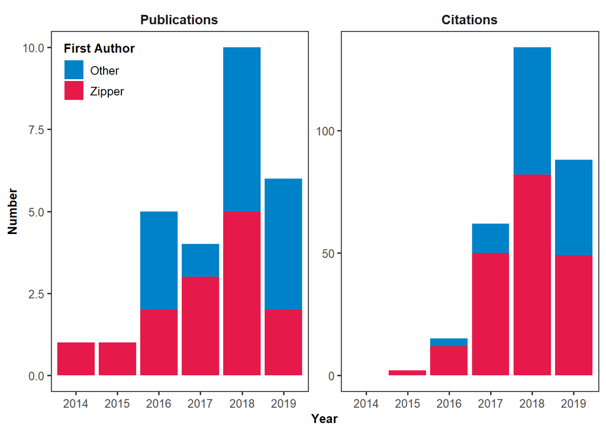

```r
ggplot(pubs_and_cites, aes(x=factor(year), y=number, fill=first_author_me)) +
  geom_bar(stat="identity") +
  facet_wrap(~factor(metric, levels=c("Publications", "Citations")),
             scales = "free_y") +
  # everything below here is just aesthetics
  scale_x_discrete(name = "Year") +
  scale_y_continuous(name = "Number") +
  scale_fill_manual(name = "First Author",
                    values = c("TRUE"="#e6194b", "FALSE"="#0082c8"),
                    labels = c("TRUE"="Zipper", "FALSE"="Other")) +
  theme_bw(base_size=12) +
  theme(panel.grid = element_blank(),
        strip.background = element_blank(),
        strip.text = element_text(size = 11, face="bold"),
        axis.title = element_text(size = 10, face="bold"),
        legend.title = element_text(size = 10, face="bold"),
        legend.position = c(0.01,0.99),
        legend.justification = c(0, 1))
```

Voila! Now, you can add it to your CV, or just print it out and hang it on the wall above your bed (I don’t judge).